# STAT 495R - Presenting Data Syllabus

Jeff Parker

Fall 2020

## Course Genesis and Pitch

The workplace is full of lots of pitfalls for aspiring data scientists, data analysis and fresh undergraduates in general. One such pitfall is in communicating the data insights - the analysis might be amazing, but it falls flat because the presentation is ugly, complicated and doesn’t tell a data story. Business stakeholders will not be as mathematically incline as data scientists. They need simple, straighforward, compelling visuals to drive a point home. This class helps students who are already brilliant statisticians become well-rounded data scientists - “a data scientist knows a little more about math than a developer, and a little more about computer programming than a business person.” My addition: “and a little more about business than a statistician.”

This course is all about helping connect the advanced data science to non-mathematical stakeholders in a digestible and impactful way. It is one part technical tools (ggplot, RShiny, Tableau, PowerPoint, R Markdown, blog down, RPages), one part data visualization principals (using the right chart type, asthestics), one part storytelling-with-data (using the right medium like dashboard, slides, documents; business communication). This all compiles into the very succint course title: “Presenting Data.”

This course will benefit any student of quantitative sciences (statistics, math, analytics, finance, econ) preparing to enter the workforce or preparing to continue into graduate school.

## Course Description

This class will help students share and communicate the awesome insights from data science projects. Students will learn techniques to convey results to non-technical business people in a compelling and impactful way. Students will dive deep into tools in R, PowerPoint and Tableau to create brilliant data visualizations, graphs and charts. The class explores different presentation mediums like notebooks, slide presentations, dashboards, blogs and websites. Students will come away from the class with tangible visual assets that they can show future employers.

## Course Objectives

- Create stunning data visualizations using ggplot and other data science tools
- Be able to tell a compelling business story with data like strategy consultants do
- Know which visualization format best conveys the insight
- Know which presentation medium is appropriate for different audiences
- Have created a useful portfolio of data visualization tools like dashboards, websites and blogs

## Prerequisites

We will touch on many common data science methods including linear regression, predictive modeling and factor/cluster analysis. But this course is NOT about how to do the data science methods, but rather how to visualize and convey the findings/results of these in a compeling way. But students do need to understand the underpinnings of the data science methods they wish to communicate in order to do so properly. The more you know about these methods, the better you will be able to convey the results. If you don’t know much about the data science methods, fear not, Google them and read a couple blog articles. Many of these blogs might use some scientific notation, proofs and formulas, but in class students will not encounter too much of this. We will avoid greek letters. STAT 223 is a soft prerequitisite.

We will also be programming in R, so students need to have taken the Intro to R class (or free online equivilant). Preferrably, students will be versed in the `tidyverse` packages. If you are unfamiliar with R and `tidyverse`, spend some time becoming familiar quickly! We will also touch a bit on Python and have full day dedicated to Tableau, but if no previous experiene is neccessary.

Lastly, business communication and etiquette is expected in this course. We are going to simulate a career working environment. The core objective of this course is business communication with a quantitative twist. MCom 320 is a soft prerequitisite.

## Contact Information

*Instructor*: Jeff Parker

1. jparker@stat.byu.edu
2. jeffparker@byu.edu

*TA*: Steven Orgill | stevenorgill@gmail.com

*Slack*: Best for class communication, announcments, crowd sourcing help, sharing stuff | Join [here](https://join.slack.com/t/newworkspace-lfk8388/shared_invite/zt-gx5vztmq-NjBNN8CcrYi6gVqA6W23eQ)

*Office Hours*: Virtual via Slack, Monday 4pm-6pm.

## Instructor Description

Jeff Parker graduated from Utah State University with a BS in Economics where he was deeply involved in the university through student government, honor programs, research and study abroads. He cut his teeth on big data analytics at a fintech company called Clearwater Analytics in Boise, Idaho. He then moved to a management consulting group in Salt Lake called Cicero Group where his love of business analytics and data science blossumed as he saw the impact it had across companies. At Cicero Group, he created 100’s of PowerPoint slides a week following analysis in R and Excel. He worked on a wide array of data science projects delivered to top level executives including target marketing, customer segmentation and loan approval. He left Cicero to attend Northwestern’s full-time, onsite Master’s of Analtyics program where he honed his data science skills and expanded his toolbox. After graduation, he joined Qualtrics to help build out a client-facing data science team which has grown from 2 to 7 in his 3 years there. In his role, he analyzes survey data and operational data using advanced techniques for paying client’s such as Google, Peloton, Uber, Amazon, Quibi, General Mills, Budweiser, Coca Cola, MLB, NASCAR, BMW and others. He uses a data-driven approach to help these companies develop their products and brand strategy.

## Course Format

This course is taught in WVB 1155 everyweek on Wednesday from 4:00pm to 6:30pm. The class will use the [“blended” model](https://enrollment.byu.edu/registrar/instruction-modes) of teaching which makes the course available both in person and remote at the set time. Students should feel equally comfortable attending in-person and remotely. As students, you are paying for this experience and so if you feel the in-person component is important, then you should attend as often as you feel comfortable in person. However, if it is preferably to you, please attend virtually. Regardless of your attendance mode, I hope to get to know you and be available to elevate your educational experience. The course will transistion to fully virtual around mid-October (depending on COVID and other health factors). There is a good chance everyone’s career will involve virtual components, so this will help simulate this.

This class is going to be very, very interactive. The virtual component will make for an interesting dynamic. When you are remote, please make an extra effort to connect and participate. Use the Zoom tools to ask questions and participate in the discussion. When you are remote, I expect the same professionalism as your employer would - mute your mic when not talking, video on when it should be, and be a respectful participant. You don’t need to be professionally dressed and upright at a desk, but you should be in an environment that is condusive to your education (e.g., not driving, at a basketball game or watching something else).

Two and half hours is a long time for a class - I know! I’ve sat through many classes this long. We will take breaks through out. If virtual, you are more than welcome to eat dinner during class - but please don’t do so in a distracting manner. I’ll rely on your feedback for when to take breaks, when to speed up/slow down the lecture, when to clarify, etc.

Lecture presentations, videos, data sets and other assets will be uploaded to GitHub and/or Learning Suite.

Each week there will be homework assignments that will need to be submitted via email by EOD Monday. Late assignment submission will be met with the same reaction a client would give in the real world - and you will be docked points.

## Time Committment

With math/stats classes, you might work and work at a problem, but eventually you find the right answer and you are done. With data visualization there is no hard stopping point - he more time you put into it, the better it becomes. However, there is a point where the increase in quality starts to diminish. It is up to students to determine when to “ship” the final product. Student’s will need to manage their time appropriately. My recommendation is to expect to spend about 3 hours per week on the homework assignments and another 2 hours of time to tangetially related research (e.g., coding videos/bootcamps, textbook reading) for a total of 5 hours (which is 2x the classroom time).

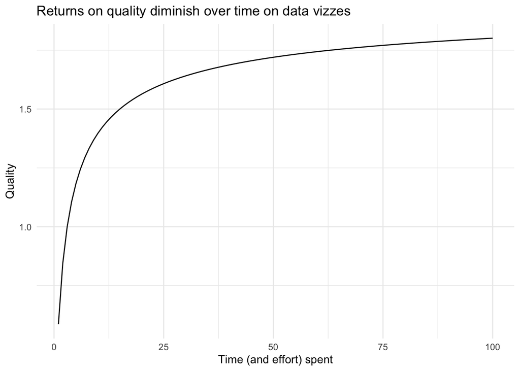

## Tools

*Computer/laptop*: Student’s will likely be downloading and installing some applications, so administrator privelages are needed. But at minimum the device should have R, RStudio and a slide editor (PowerPoint will be taught and is preferred, but Google Slides or Apple Keynote works in a pinch).

## Grading

This is an elective class taught by an adjunct - if you demonstrate baseline *effort* and *compendency* while being *respectful* you can expect a high letter. Grading will be generous but the more you put into this class, the more you will get out of it (as with any class). My recommendation is to worry less about the grade and focus more on the learning.

Weekly assignments will be point-based:

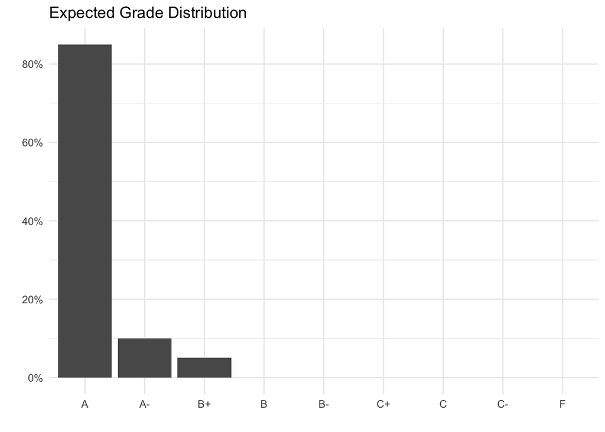

Participation is a core component of the class. The default assumption is that everyone is participating at an appropriate level. If I notice a student is not participating, I will warn him/her. If a warned student still does not participate, then grades might be adversely affected.

There will not be a final exam.

## Feedback

“Presenting Data” grading is subjective - similiar to how an English professor needs to be subjective when grading an essay. You may think your work is just amazing but I may subjectively disagree. I will do my best to grade according to sound principals and provide lots of feedback. Students should feel comfortable receiving feedback - you are going to get it and some will be positive and some will be constructive. There will not be any “Oreo” styled feedback (a constructive criticism sandwiched in 2 complements) - I try to give radical candor to help students learn and grow.

Students should also be comfortable sharing their work with classmates/peers and soliciting feedback. It is difficult to be vulnerable when doing this. However, the more opinions you get on your work the better your future work becomes. Students should be kind when providing feedback (positive or constructive).

## Course Structure and Schedule

The intention is to follow the schedule, but we may deviate from this if it’s in the best interest of the class.

### *Week 1* - Sept 2

- Syllabus review
- Different modes: slides, documents, sliduments, dashboards
- Understanding context
- Elements of a PowerPoint templates
- Showcase of PPT templates
- Working in PowerPoint slide master view
- Post class reading: SWD, Intro and Chapter 1
- Homework: Create a PowerPoint Template

### *Week 2* - Sept 9

- Choosing the right visualization
- The Power 6 visualization types in PowerPoint
- Elements of a graphic
- Removing clutter and advanced paint work
- Advanced options in PowerPoint graphing
- Post class reading: SWD Chapter 2, 3
- Homework: Recreate several graphs so they don’t suck

### *Week 3* - Sept 16

- Making the visualization impactful
- Gesault principals
- Getting into ggplot
- Post class reading: SWD Chapter 4, 5, 6
- Homework: Moving from NPS to CSAT for bonus compensation; 5-minute story and big ideas

### *Week 4* - Sept 23

- Moving beyond 1 page to a full deck
- Telling a good story
- What, so what, now what
- Storyboarding/Wireframing/Dot Dash
- More ggplot
- Post class reading: SWD Chapter 7, 8, Gapminder Ted Talk
- Homework: Presentation on “magic moments”; story-board

### *Week 5* - Sept 30

- Non-standard visualization types
- More ggplot
- R Presentation
- Post class reading: SWD Chapter 9, 10, Sound Visualization Podcast
- Homework: Refute a political claim with data

### *Week 7* - Oct 14

- From presentations to documents
- Principals of writing
- Integrating documents and websites
- RMarkdown and Blogdown
- Post class reading: r4ds Chapter 29
- Homework: document data analysis steps for optimal scheduling

### *Week 8* - Oct 21

- Interactivity tools
- plotly, htmlwidgets
- Homework: Where are our customers going? Analyzing vehicle data.

### *Week 10* - Nov 4

- Tableau Day - Making a Spicy Dashboard
- Guest Lecturer: Matt Farkas, Data Scientist at Spotify and [Tableau Data Astronaut](https://www.tableau.com/about/blog/2018/7/generation-data-matt-farkas-spotify-intern-90972)
- Assignment: Create a spicy Tableau dashboard from a provided dataset

### *Week 11* - Nov 11

- RShiny
- What Dashboards do that other medium can’t
- Why RShiny
- Homework: create an RShiny dashboard to explore baby names

### *Week 13* - Nov 25

**No class; Thankgiving Break**

### *Week 14* - Dec 2

- Presentation showcase
- Feedback roundtable

### *Week 15* - Dec 9

- Flex week - cover what was not yet covered
- Python and Matplotlib

### *Week 16* - Dec 16

**No class; Final Exam week**

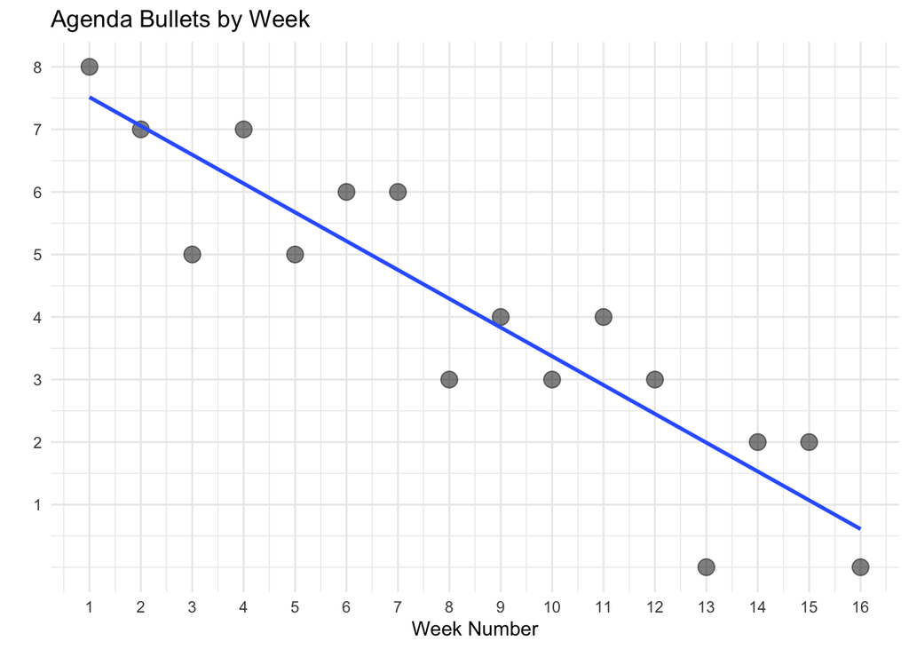

## Textbooks

Storytelling with data by Cole Nussbaumer Knaflic. It’s definitely worth the cost for the hard copy. I find myself referencing it and sharing this book often.

R for Data Science by Hadley Wickham. Free at https://r4ds.had.co.nz/

Alternate excellent resources include:

- [Flowing Data Blog](https://flowingdata.com/)
- [Mastering Shiny](https://mastering-shiny.org/)
- Storytelling with Data Blog
- [Banana Data Newsletter’s Top Dataviz of the Week](https://banana-data.com/)
- [New York Times’ The Upshot](https://www.nytimes.com/section/upshot)
- The Economist
- Five Thrity Eight
- Instagram
- Google
- The Internet
- Stack Overflow

## Respectful Environment

*Respect* for all is requested and required of all involved. Students should exhibit respect for each other by being polite in questions, helpful in study groups and attentive during lectures. Students should exhibit respect for themselves by coming to class prepared and anxious to learn, homework completed, participating in discussions as needed. Students should show respect to the instructor by being patient, forgiving and polite. The instructor should show respect to students by being prepared, honest and by going the extra mile to facilitate learning.

## Honor Code

In keeping with the principles of the BYU Honor Code, students are expected to be honest in all of their academic work. Academic honesty means, most fundamentally, that any work you present as your own must in fact be your own work and not that of another. Violations of this principle may result in a failing grade in the course and additional disciplinary action by the university. Students are also expected to adhere to the Dress and Grooming Standards. Adherence demonstrates respect for yourself and others and ensures an effective learning and working environment. It is the university’s expectation, and every instructor’s expectation in class, that each student will abide by all Honor Code standards. Please call the Honor Code Office at 422-2847 if you have questions about those standards.

## Preventing & Responding to Sexual Misconduct

In accordance with Title IX of the Education Amendments of 1972, Brigham Young University prohibits unlawful sex discrimination against any participant in its education programs or activities. The university also prohibits sexual harassment-including sexual violence-committed by or against students, university employees, and visitors to campus. As outlined in university policy, sexual harassment, dating violence, domestic violence, sexual assault, and stalking are considered forms of “Sexual Misconduct” prohibited by the university.

University policy requires all university employees in a teaching, managerial, or supervisory role to report all incidents of Sexual Misconduct that come to their attention in any way, including but not limited to face-to-face conversations, a written class assignment or paper, class discussion, email, text, or social media post. Incidents of Sexual Misconduct should be reported to the Title IX Coordinator at t9coordinator@byu.edu or (801) 422-8692. Reports may also be submitted through EthicsPoint at https://titleix.byu.edu/report or 1-888-238-1062 (24-hours a day).

BYU offers confidential resources for those affected by Sexual Misconduct, including the university’s Victim Advocate, as well as a number of non-confidential resources and services that may be helpful. Additional information about Title IX, the university’s Sexual Misconduct Policy, reporting requirements, and resources can be found at http://titleix.byu.edu or by contacting the university’s Title IX Coordinator.

## Student Disability

Brigham Young University is committed to providing a working and learning atmosphere that reasonably accommodates qualified persons with disabilities. A disability is a physical or mental impairment that substantially limits one or more major life activities. Whether an impairment is substantially limiting depends on its nature and severity, its duration or expected duration, and its permanent or expected permanent or long-term impact. Examples include vision or hearing impairments, physical disabilities, chronic illnesses, emotional disorders (e.g., depression, anxiety), learning disorders, and attention disorders (e.g., ADHD). If you have a disability which impairs your ability to complete this course successfully, please contact the University Accessibility Center (UAC), 2170 WSC or 801-422-2767 to request a reasonable accommodation. The UAC can also assess students for learning, attention, and emotional concerns. If you feel you have been unlawfully discriminated against on the basis of disability, please contact the Equal Employment Office at 801-422-5895, D-285 ASB for help.”

## COVID 19 Statement

Please be attentive to all University COVID 19 announcements and adhere to policies set by the University.

While COVID 19 conditions persist and until further notice, students and faculty are required to wear face coverings at all times during class; faculty are not at liberty to waive this expectation.

Students who feel sick, including exhibiting symptoms commonly associated with COVID 19 (fever; cough; shortness of breath/difficulty breathing; chills; muscle pain; sore throat; new loss of taste or smell; etc.) should not attend class and should work with their instructor to develop a study plan for the duration of the illness.